# DGE analysis of SLCs

```r
# 2024.3.24
#if (!requireNamespace("BiocManager", quietly = TRUE))
#    install.packages("BiocManager")
#BiocManager::install("biomaRt")

#library(biomaRt)
```

```r
library(tidyverse)
```

```r
#library(stringr)
#library(dplyr)
library(limma)
library(edgeR)
library(ggplot2)
library(ggdendro)
library(pvclust)
library(gplots)
library(cluster)
library(igraph)
library(goseq)
library(treemap)
library(clusterProfiler)
library(org.Hs.eg.db)
library(RColorBrewer)
```

First we copy the [list of SLCs in mammalian genomes](https://esbl.nhlbi.nih.gov/Databases/SLC-list/) and convert gene IDs to ENSG IDs with tool on this [page](https://biit.cs.ut.ee/gprofiler/convert).Then we can select all SLCs in GTEx gene counts data file with `filter.py` in terminal.

```bash
python filter.py -f1 ../Input/gProfiler_hsapiens_12-11-2023_6-02-56\ AM.csv -f2 ../Input/bulk-gex_v8_rna-seq_GTEx_Analysis_2017-06-05_v8_RNASeQCv1.1.9_gene_reads.gct -o ../Input/GTEx_SLCs_gene_reads.gct
```

```r
tissue1 <- 'Breast'

# Load count data
counts.data <- read_tsv("../Input/GTEx_SLCs_gene_reads.gct")
samp.anno.data <- read_tsv("../Input/GTEx_Analysis_v8_Annotations_SampleAttributesDS.txt")
subj.anno.ds.data <- read_tsv("../Input/GTEx_Analysis_v8_Annotations_SubjectPhenotypesDS.txt")
```

```r
counts.data <- counts.data[,-1]

#counts.data.backup <- counts.data
#counts.data <- counts.data.backup

select <- dplyr::select

# Retrieve the count data of 2 among so many various tissues to analyse. Subsequent analysis should include all the data
tiss1.sampid <- samp.anno.data %>%
  filter(SMTS==tissue1) %>%
  select(SAMPID,SMTSD)

#tiss2.sampid <- samp.anno.data %>%
#  filter(SMTS==tissue2) %>%
#  select(SAMPID)

#counts.data <- counts.data.backup

#ids <- tiss1.sampid %>%
#  bind_rows(tiss2.sampid) %>%
#  add_row(SAMPID='Description') %>%
#  pull() %>%
#  paste(collapse="|")

ids <- tiss1.sampid %>%
#  bind_rows(tiss2.sampid) %>%
  add_row(SAMPID='Description') %>%
  .$SAMPID


counts.data <- counts.data %>%
  select(any_of(ids))

missing_ids <- ids[!ids %in% colnames(counts.data)]

#counts.data <- counts.data %>%
#  select(matches(ids))

genelist <- counts.data$Description

# For our subsequent analyses we want to reduce the data set to only those genes with some expression. In this case we will discard genes with no reads in >= 50 samples
counts.data <- counts.data[rowSums(counts.data[,-1]==0)<50,]

#cor.table <- cor(counts.data[,-1])
#cor.table %>% gplots::heatmap.2(dendrogram="row", trace = "none", col=viridis::viridis(25, begin=.25), margins=c(7,8))

# Create a tibble for edgeR description
#tiss1.sampid <- tiss1.sampid %>%
#  mutate(TS=tissue1)

#tiss2.sampid <- tiss2.sampid %>%
#  mutate(TS=tissue2)
```

Before we can normalize the data we need to be able to tell edgeR which groups the samples belong to. Here group refers to the distinct sample types (i.e. combinations of tissue, age, death circumstance)

```r
sample.description <- tiss1.sampid %>%
#  bind_rows(tiss2.sampid) %>%
  mutate(SUBJID=str_extract(SAMPID, 'GTEX-.+(?=-.+-SM)')) %>%
  left_join(subj.anno.ds.data, by='SUBJID') %>%
  mutate(group=paste(SMTSD, SEX, AGE, DTHHRDY, sep="_")) %>% # TS to SMTSD
  select(-SUBJID)

colnames(sample.description)[2] <- 'TS'

#sample.description <- sample.description %>%
#  mutate(SMTSD=factor(SMTSD,level = c("Brain - Frontal Cortex (BA9)","Brain - Cortex","Brain - Cerebellum","Brain - Cerebellar Hemisphere","Brain - Caudate (basal ganglia)","Brain - Nucleus accumbens (basal ganglia)","Brain - Putamen (basal ganglia)","Brain - Hypothalamus","Brain - Spinal cord (cervical c-1)","Brain - Hippocampus","Brain - Anterior cingulate cortex (BA24)","Brain - Substantia nigra","Brain - Amygdala")),
#         SEX=factor(SEX,levels = c(1,2)),
#         AGE=factor(AGE,levels = c("20-29","30-39","40-49","50-59","60-69","70-79")),
#         DTHHRDY=factor(DTHHRDY,levels = c(0,1,2,3,4)))

sample.description <- sample.description %>%
  mutate(
    TS = factor(TS, levels = unique(TS)),
    SEX = factor(SEX, levels = sort(unique(SEX))),  # numeric should be sorted
    AGE = factor(AGE, levels = c("20-29", "30-39", "40-49", "50-59", "60-69", "70-79")),
    DTHHRDY = factor(DTHHRDY, levels = sort(unique(DTHHRDY)))  # sort numerically
  )

sample.description
```

| SAMPID | TS | SEX | AGE | DTHHRDY | group |
| --- | --- | --- | --- | --- | --- |
| GTEX-1117F-2826-SM-5GZXL | Breast - Mammary Tissue | 2 | 60-69 | 4 | Breast - Mammary Tissue_2_60-69_4 |
| GTEX-111YS-1926-SM-5GICC | Breast - Mammary Tissue | 1 | 60-69 | 0 | Breast - Mammary Tissue_1_60-69_0 |
| GTEX-1122O-1226-SM-5H113 | Breast - Mammary Tissue | 2 | 60-69 | 0 | Breast - Mammary Tissue_2_60-69_0 |
| GTEX-117XS-1926-SM-5GICO | Breast - Mammary Tissue | 1 | 60-69 | 2 | Breast - Mammary Tissue_1_60-69_2 |
| GTEX-117YX-1426-SM-5H12H | Breast - Mammary Tissue | 1 | 50-59 | 0 | Breast - Mammary Tissue_1_50-59_0 |
| GTEX-1192X-2326-SM-5987X | Breast - Mammary Tissue | 1 | 50-59 | 4 | Breast - Mammary Tissue_1_50-59_4 |
| GTEX-11DXW-0626-SM-5N9ER | Breast - Mammary Tissue | 1 | 40-49 | 2 | Breast - Mammary Tissue_1_40-49_2 |
| GTEX-11DXY-2326-SM-5GICW | Breast - Mammary Tissue | 1 | 60-69 | 2 | Breast - Mammary Tissue_1_60-69_2 |
| GTEX-11DXZ-1926-SM-5GZZL | Breast - Mammary Tissue | 1 | 50-59 | 0 | Breast - Mammary Tissue_1_50-59_0 |
| GTEX-11DZ1-0326-SM-5N9BN | Breast - Mammary Tissue | 1 | 50-59 | 4 | Breast - Mammary Tissue_1_50-59_4 |

[output cut: 470 more lines]

Calculate normalization factors by TMM method while RPKM is poorly behaved statistically, and plot multidimensional scaling plot of distances between gene expression profiles by logFC methods instead of bcv due to the large quantity of samples

```r
counts.matrix <- counts.data %>% select(-Description) %>% as.matrix()
rownames(counts.matrix) <- counts.data$Description

sample.description <- tibble(SAMPID=colnames(counts.matrix)) %>%
  left_join(sample.description, by = join_by(SAMPID))

dge.data <- DGEList(counts=counts.matrix,
                    group=sample.description$group)

dge.data <- calcNormFactors(dge.data, method = "TMM")
dge.data$samples
```

|  | group | lib.size | norm.factors |
| --- | --- | --- | --- |
| GTEX-1117F-2826-SM-5GZXL | Breast - Mammary Tissue_2_60-69_4 | 508396 | 1.0751353 |
| GTEX-111YS-1926-SM-5GICC | Breast - Mammary Tissue_1_60-69_0 | 678442 | 1.0488492 |
| GTEX-1122O-1226-SM-5H113 | Breast - Mammary Tissue_2_60-69_0 | 644492 | 1.0821723 |
| GTEX-117XS-1926-SM-5GICO | Breast - Mammary Tissue_1_60-69_2 | 721016 | 0.9585095 |
| GTEX-117YX-1426-SM-5H12H | Breast - Mammary Tissue_1_50-59_0 | 533542 | 0.8655554 |
| GTEX-1192X-2326-SM-5987X | Breast - Mammary Tissue_1_50-59_4 | 653657 | 1.0435280 |
| GTEX-11DXW-0626-SM-5N9ER | Breast - Mammary Tissue_1_40-49_2 | 616236 | 1.0649655 |
| GTEX-11DXY-2326-SM-5GICW | Breast - Mammary Tissue_1_60-69_2 | 444473 | 1.0626652 |
| GTEX-11DXZ-1926-SM-5GZZL | Breast - Mammary Tissue_1_50-59_0 | 606483 | 0.9591326 |
| GTEX-11DZ1-0326-SM-5N9BN | Breast - Mammary Tissue_1_50-59_4 | 714447 | 0.9340288 |

[output cut: 449 more lines]

```r
# Make a plot of the Biological Coefficient of Variation of each sample

# Try to find out if sample can be divided by variables (i.e. TS, AGE, SEX)

#plotMDS(dge.data,method="logFC",pch=matched_pchs,bg=matched_bgs,col=matched_cols,
#        cex=1.4, dim.plot=c(3,2))
```

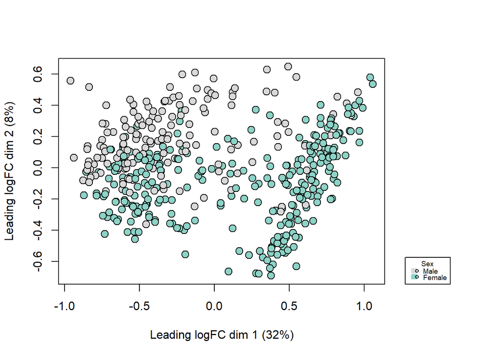

```r
# Assuming sample.description is your data frame
#plot_info <- sample.description %>%
#  mutate(
#    AGE = factor(AGE),
#    SEX = factor(SEX, levels = c(1, 2), labels = c("Male", "Female")),
#    TS = factor(TS)  # TS column is same as SMTSD
#  )

plot_info <- sample.description %>%
  mutate(
    SEX = factor(SEX, levels = c(1, 2), labels = c("Male", "Female")),
    TS = factor(TS),
    AGE = as.character(AGE), #When AGE is a factor and ifelse() is used, it doesn't handle factors gracefully
    AGE = ifelse(is.na(AGE), "Unknown", AGE),# Handle missing AGE
    AGE = factor(AGE, levels = c("20-29", "30-39", "40-49", "50-59", "60-69", "70-79", "Unknown"))
      )


# Define colors and shapes dynamically
#library(RColorBrewer)
#display.brewer.pal(12, "Set3")

#colors_age <- RColorBrewer::brewer.pal(n = length(unique(plot_info$AGE)), name = "Set1")
#colors_tissue <- RColorBrewer::brewer.pal(n = length(unique(plot_info$TS)), name = "Set3")

#colors_tissue <- RColorBrewer::brewer.pal(n = length(unique(plot_info$TS)), name = "Set3")
colors_tissue <- colorRampPalette(RColorBrewer::brewer.pal(9, "Set3"))(length(unique(plot_info$SEX)))

# Assign colors and shapes
#plot_info <- plot_info %>%
#  mutate(
#    col = colors_tissue[TS],  # Tissue colors
#    bg = colors_age[AGE],     # Age background colors
#    pch = ifelse(SEX == "Male", 21, 24)  # Sex shapes
#  )

#plot_info <- plot_info %>%
#  mutate(
#    bg = colors_tissue[TS],  # Tissue background colors
#    pch = ifelse(SEX == "Male", 21, 24)  # Sex shapes
#  )

plot_info <- plot_info %>%
  mutate(
    bg = colors_tissue[SEX], # Tissue colors
  )


matched_bgs <- plot_info$bg[match(colnames(dge.data), plot_info$SAMPID)]
#matched_pchs <- plot_info$pch[match(colnames(dge.data), plot_info$SAMPID)]
#matched_cols <- plot_info$col[match(colnames(dge.data), plot_info$SAMPID)]


# Increase the right margin to make space for the legend
par(mar=c(5, 4, 4, 8) + 0.1)  # Default is c(5, 4, 4, 2) + 0.1



#plotMDS(dge.data,method="logFC",pch=matched_pchs,bg=matched_bgs,col=matched_cols,
#        cex=1.4, dim.plot=c(1,2))

plotMDS(dge.data,method="logFC",pch=21,bg=matched_bgs,cex=1.4,
        dim.plot=c(1,2))

# Adding a legend for Age outside the bottom of the plot
#legend("topright", inset=c(-0.2, 0.2), title="Age", legend=levels(plot_info$AGE), fill=unique(plot_info$bg), cex=0.8, y.intersp=0.7, xpd=TRUE)
# Adding a legend for Sex outside the top left of the plot
#legend("topright", inset=c(-0.2, 0), title="Sex", legend=levels(plot_info$SEX), pch=unique(plot_info$pch), cex=0.6, y.intersp=0.7, xpd=TRUE)
# Adding a legend for Tissue outside the top right of the plot
legend("bottomright", inset=c(-0.2, 0), title="Sex", legend=levels(plot_info$SEX), fill=unique(plot_info$bg), pch=21, cex=0.6, y.intersp=0.7, border=unique(plot_info$bg), xpd=TRUE)
```

```r
# Assuming sample.description is your data frame
plot_info <- sample.description %>%
  mutate(
    AGE = factor(AGE),
    SEX = factor(SEX, levels = c(1, 2), labels = c("Male", "Female")),
    TS = factor(TS)  # TS column is same as SMTSD
  )

# Define colors and shapes dynamically
#library(RColorBrewer)
#display.brewer.pal(12, "Set3")

#colors_age <- RColorBrewer::brewer.pal(n = length(unique(plot_info$AGE)), name = "Set1")
#colors_tissue <- RColorBrewer::brewer.pal(n = length(unique(plot_info$TS)), name = "Set3")

#colors_age <- RColorBrewer::brewer.pal(n = length(unique(plot_info$AGE)), name = "Set3")
colors_age <- colorRampPalette(RColorBrewer::brewer.pal(9, "Set3"))(length(unique(plot_info$AGE)))


# Assign colors and shapes
#plot_info <- plot_info %>%
#  mutate(
#    col = colors_tissue[TS],  # Tissue colors
#    bg = colors_age[AGE],     # Age background colors
#    pch = ifelse(SEX == "Male", 21, 24)  # Sex shapes
#  )

plot_info <- plot_info %>%
  mutate(
    bg = colors_age[AGE],  # Tissue background colors
    pch = ifelse(SEX == "Male", 21, 24)  # Sex shapes
  )


matched_bgs <- plot_info$bg[match(colnames(dge.data), plot_info$SAMPID)]
matched_pchs <- plot_info$pch[match(colnames(dge.data), plot_info$SAMPID)]
#matched_cols <- plot_info$col[match(colnames(dge.data), plot_info$SAMPID)]


# Increase the right margin to make space for the legend
par(mar=c(5, 4, 4, 8) + 0.1)  # Default is c(5, 4, 4, 2) + 0.1



#plotMDS(dge.data,method="logFC",pch=matched_pchs,bg=matched_bgs,col=matched_cols,
#        cex=1.4, dim.plot=c(1,2))

plotMDS(dge.data,method="logFC",pch=matched_pchs,bg=matched_bgs,cex=1.4,
        dim.plot=c(1,2))

# Adding a legend for Age outside the bottom of the plot
#legend("topright", inset=c(-0.2, 0.2), title="Age", legend=levels(plot_info$AGE), fill=unique(plot_info$bg), cex=0.8, y.intersp=0.7, xpd=TRUE)
# Adding a legend for Sex outside the top left of the plot
legend("topright", inset=c(-0.2, 0), title="Sex", legend=levels(plot_info$SEX), pch=unique(plot_info$pch), cex=0.8, y.intersp=0.7, xpd=TRUE)
# Adding a legend for Tissue outside the top right of the plot
legend("bottomright", inset=c(-0.2, 0), title="Age", legend=levels(plot_info$AGE), fill=unique(plot_info$bg), pch=21, cex=0.8, y.intersp=0.7, border=unique(plot_info$bg), xpd=TRUE)
```

[output not shown]

```r
# Filter out genes with low mean normalized counts (no need to do it as there's
# no gene could be filterd out here)
#avg_log_cpm <- rowMeans(cpm(dge.data, log=TRUE))
#min_log_cpm <- 0.5  # For example, log2 CPM of 0.5
#keep <- avg_log_cpm > min_log_cpm
#counts_filtered_final <- counts.matrix[keep, ]

counts.data.normal <- cpm(dge.data)

# or log2 transformed:
counts.data.normal.log <- cpm(dge.data,log = TRUE)

# Assuming the first column might be non-numeric and should be excluded from the operation
counts.data[,-1] <- sapply(counts.data[,-1], function(x) as.numeric(as.character(x)))
# Check if there are any NAs introduced by incorrect conversions
sum(is.na(counts.data))
```

```
## [1] 350
```

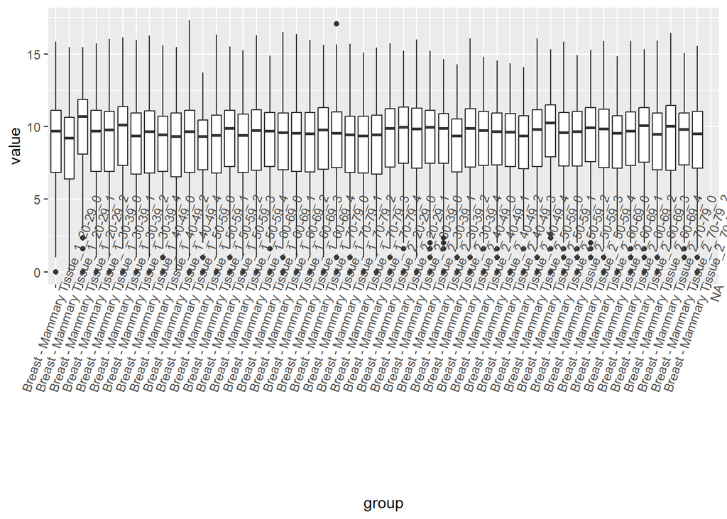

```r
counts.data.log <- log2(counts.data[,-1] + 1)

counts.data.log.pvt <- counts.data.log

counts.data.log.pvt <- counts.data.log.pvt %>%
  pivot_longer(colnames(counts.data.log.pvt), names_to="sample", values_to="value")

counts.data.log.pvt <- sample.description %>%
  select(SAMPID, group) %>%
  right_join(counts.data.log.pvt, by=join_by(SAMPID==sample))

counts.data.log.pvt %>% ggplot(aes(x=group, y=value)) +
  geom_boxplot() +
  theme(axis.text.x = element_text(angle = 70))
```

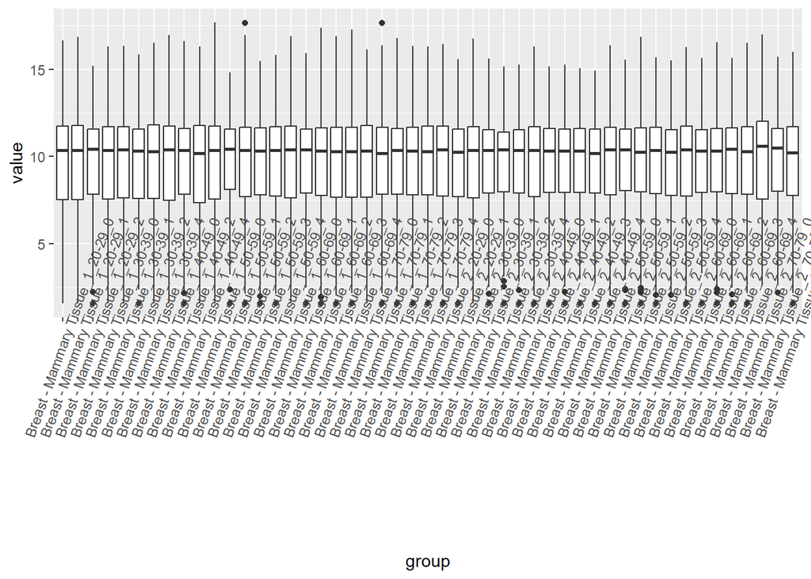

```r
counts.data.normal.log.pvt <- as.data.frame(counts.data.normal.log)


counts.data.normal.log.pvt <- counts.data.normal.log.pvt %>%
  pivot_longer(colnames(counts.data.normal.log.pvt), names_to="sample", values_to="value")

counts.data.normal.log.pvt <- sample.description %>%
  select(SAMPID, group) %>%
  right_join(counts.data.normal.log.pvt, by=join_by(SAMPID==sample))

counts.data.normal.log.pvt %>% ggplot(aes(x=group, y=value)) +
  geom_boxplot() +
  theme(axis.text.x = element_text(angle = 70))
```

```r
# Now calculate dispersion factors
design <- model.matrix(~SEX,data = sample.description)
rownames(design) <- sample.description$SAMPID

# First the overall dispersion
dge.data <- estimateGLMCommonDisp(dge.data,design,verbose = TRUE)
```

```
## Disp = 0.39237 , BCV = 0.6264
```

```r
# Then a trended dispersion based on count level
dge.data <- estimateGLMTrendedDisp(dge.data,design)

# And lastly we calculate the gene-wise dispersion, using the prior estimates to
#"squeeze" the dispersion towards the common dispersion.
dge.data <- estimateGLMTagwiseDisp(dge.data,design)
```

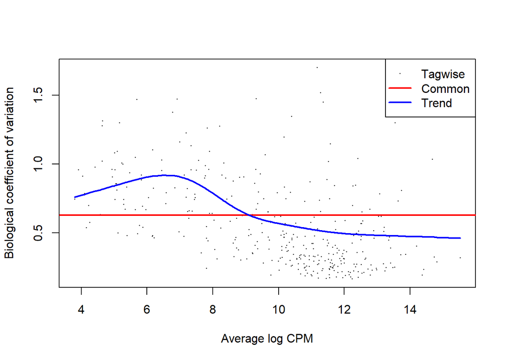

```r
# Draw dispersion plot
plotBCV(dge.data)
```

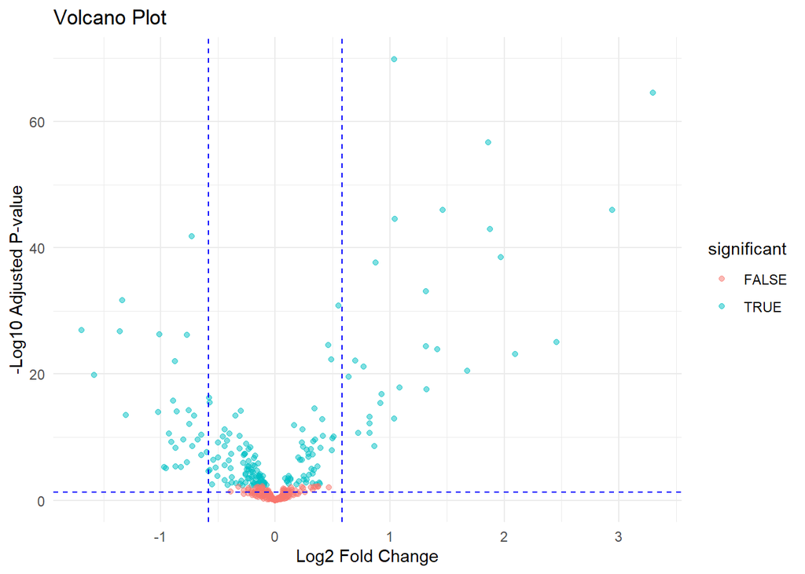

```r
# Find genes that expressed differently in these 2 tissues
fit <- glmFit(dge.data, design)

ts.lrt <- glmLRT(fit,coef="SEX2")

# label genes with a FDR < 0.05 and a fold change > 1.5 and draw a volcano plot
results <- topTags(ts.lrt, n=Inf)$table
results$significant <- results$FDR < 0.01 & abs(results$logFC) > log2(1)
results$PValue <- pmax(results$PValue, 1e-300)  # replace exact 0s with a very small number

results$SignificanceLabel <- ifelse(results$significant, "Significant", "Not Significant")

ggplot(results, aes(x = logFC, y = -log10(PValue), col=significant)) +
  geom_point(alpha = 0.5) +
  geom_vline(xintercept = c(-log2(1.5),log2(1.5)), linetype="dashed",color="blue") +  # LogFC lines
  geom_hline(yintercept = -log10(0.05),linetype = "dashed",color = "blue") +  # FDR lin
  theme_minimal() +
  labs(x="Log2 Fold Change", y="-Log10 Adjusted P-value", title = "Volcano Plot")
```

```r
# Summarize the number of differentially expressed genes
summary(decideTestsDGE(ts.lrt,p.value=0.05,lfc=log2(1.5)))
```

```
##        SEX2
## Down     29
## NotSig  293
## Up       28
```

```r
## Go enrichment analysis left to do here
```

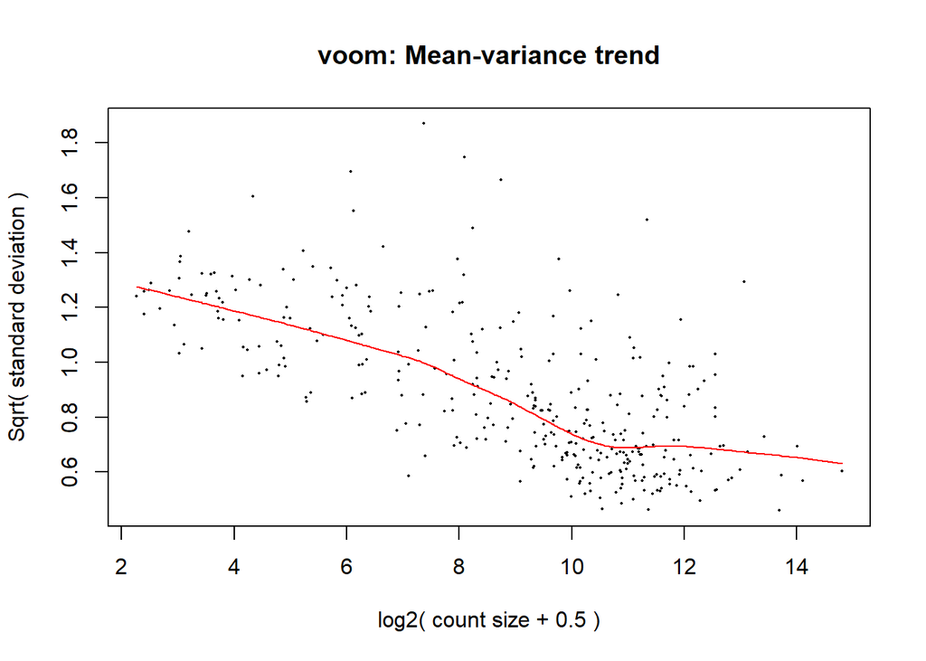

```r
## As Most of the simplest clustering assumes data to be from a normal
##distribution. we need to transformed the RNAseq data to be normally
##distributed

v <- voom(counts.matrix, design, plot=TRUE)
```

```r
voom_E <- as.data.frame(v$E) %>%
  rownames_to_column(var = "GeneID")

voom_Et <- voom_E %>%
  t() %>%
  as.data.frame() %>%
  rownames_to_column(var = "SAMPID") %>%
  left_join(sample.description,by="SAMPID")

colnames(voom_Et) <- c("SAMPID",voom_Et[1,2:(ncol(voom_Et)-5)],1,2,3,4,"group")
voom_Et <- voom_Et[-1,-(ncol(voom_Et)-4):-(ncol(voom_Et)-1)] %>%
  mutate(across(c(2:(ncol(voom_Et)-5)), as.numeric))

#voom_E

mean_vals <- voom_Et %>%
  group_by(group) %>%
  summarise(across(where(is.numeric), mean, na.rm = TRUE))
mean_vals_t <- mean_vals %>%
  t()
colnames(mean_vals_t) <- mean_vals_t[1,]

mean_vals_t <- mean_vals_t[-1,] %>%
  as.data.frame() %>%
  mutate(across(c(1:ncol(mean_vals_t)), ~as.numeric(.)))

mean_vals_t
```

|  | Breast - Mammary Tissue_1_20-29_0 | Breast - Mammary Tissue_1_20-29_1 | Breast - Mammary Tissue_1_20-29_2 | Breast - Mammary Tissue_1_30-39_0 | Breast - Mammary Tissue_1_30-39_1 | Breast - Mammary Tissue_1_30-39_2 | Breast - Mammary Tissue_1_30-39_4 | Breast - Mammary Tissue_1_40-49_0 | Breast - Mammary Tissue_1_40-49_2 | Breast - Mammary Tissue_1_40-49_4 | Breast - Mammary Tissue_1_50-59_0 | Breast - Mammary Tissue_1_50-59_1 | Breast - Mammary Tissue_1_50-59_2 | Breast - Mammary Tissue_1_50-59_3 | Breast - Mammary Tissue_1_50-59_4 | Breast - Mammary Tissue_1_60-69_0 | Breast - Mammary Tissue_1_60-69_1 | Breast - Mammary Tissue_1_60-69_2 | Breast - Mammary Tissue_1_60-69_3 | Breast - Mammary Tissue_1_60-69_4 | Breast - Mammary Tissue_1_70-79_0 | Breast - Mammary Tissue_1_70-79_1 | Breast - Mammary Tissue_1_70-79_2 | Breast - Mammary Tissue_1_70-79_3 | Breast - Mammary Tissue_1_70-79_4 | Breast - Mammary Tissue_2_20-29_0 | Breast - Mammary Tissue_2_20-29_1 | Breast - Mammary Tissue_2_30-39_0 | Breast - Mammary Tissue_2_30-39_1 | … |
| --- | --- | --- | --- | --- | --- | --- | --- | --- | --- | --- | --- | --- | --- | --- | --- | --- | --- | --- | --- | --- | --- | --- | --- | --- | --- | --- | --- | --- | --- | --- |
| SLC45A1 | 9.206203 | 8.565342 | 9.147163 | 9.180123 | 9.303314 | 9.673670 | 8.790758 | 9.312475 | 9.260020 | 8.929265 | 9.141935 | 9.4428270 | 9.150572 | 9.201742 | 9.037584 | 9.178566 | 9.159690 | 9.176506 | 9.063461 | 9.010765 | 9.103566 | 9.2058210 | 9.4972930 | 9.685508 | 9.181592 | 8.776856 | 8.045444 | 9.020415 | 8.5865260 | … |
| SLC2A5 | 8.895686 | 6.998281 | 8.634081 | 7.882547 | 9.483595 | 8.290106 | 9.576205 | 8.363069 | 8.642712 | 9.179513 | 8.461220 | 7.7507500 | 8.872783 | 8.494636 | 8.484450 | 8.508534 | 8.864076 | 8.969488 | 9.491688 | 8.329553 | 9.352181 | 9.0314840 | 8.1696740 | 8.292143 | 9.361175 | 8.911827 | 7.670974 | 8.059503 | 9.8241640 | … |
| SLC25A33 | 10.269872 | 10.999647 | 9.760095 | 10.128746 | 11.539464 | 10.354610 | 9.758366 | 10.276961 | 10.089878 | 9.831015 | 10.159262 | 10.1154040 | 10.505287 | 10.080062 | 10.084166 | 10.019462 | 10.073976 | 10.354127 | 10.145690 | 9.976372 | 10.263594 | 10.3199850 | 10.0085960 | 10.144014 | 10.153686 | 9.892384 | 10.498629 | 10.171338 | 10.5134160 | … |
| SLC25A34 | 8.513256 | 9.093361 | 9.119035 | 8.610390 | 8.532739 | 8.380213 | 7.964363 | 8.258444 | 8.563734 | 8.662155 | 8.521007 | 9.1521730 | 8.468311 | 8.322753 | 8.614623 | 8.509775 | 8.420036 | 8.301464 | 8.874837 | 8.663914 | 8.332624 | 7.7640070 | 7.7909140 | 8.622991 | 8.993064 | 8.736073 | 9.099051 | 8.580158 | 9.0467270 | … |
| NIPAL3 | 10.852479 | 10.552841 | 11.975913 | 11.095621 | 11.098198 | 10.968882 | 10.126595 | 10.976163 | 10.900607 | 10.160597 | 10.923731 | 11.4408900 | 10.521391 | 10.914060 | 10.939448 | 10.661084 | 10.982536 | 10.823863 | 10.559620 | 10.637678 | 9.947979 | 10.2852620 | 10.8086920 | 10.577967 | 10.390351 | 11.243677 | 11.435365 | 11.302524 | 12.0444170 | … |
| SLC30A2 | 2.780263 | 2.746399 | 7.728639 | 3.694573 | 1.497855 | 4.434797 | 2.388998 | 3.143841 | 4.957867 | 3.852430 | 3.919428 | 4.9599780 | 3.735125 | 3.966820 | 3.643016 | 3.643245 | 5.622079 | 3.896847 | 4.082671 | 3.679065 | 3.220022 | 3.6930720 | 4.5871070 | 3.933493 | 5.149676 | 6.313745 | 5.603181 | 5.478025 | 6.5082100 | … |
| SLC9A1 | 11.547030 | 11.512140 | 12.976320 | 11.804200 | 11.624830 | 11.956480 | 11.670210 | 11.782670 | 11.763380 | 11.522200 | 11.631900 | 12.5732200 | 11.745040 | 12.194980 | 11.668040 | 11.757430 | 12.317110 | 11.903370 | 11.714290 | 11.635640 | 11.428790 | 11.1944900 | 12.1277600 | 11.603900 | 11.757820 | 12.045610 | 12.536640 | 11.886530 | 12.6921400 | … |
| MFSD2A | 8.365965 | 6.806206 | 9.812264 | 8.745413 | 7.280225 | 7.747142 | 9.212781 | 8.565510 | 8.993255 | 7.914709 | 8.333358 | 7.0026230 | 8.225969 | 10.379003 | 8.926998 | 9.044345 | 8.091549 | 8.400234 | 8.700161 | 8.596594 | 8.179453 | 9.7011980 | 8.8676920 | 7.240703 | 8.256143 | 9.984406 | 9.043177 | 8.203063 | 8.8490900 | … |
| SLC2A1 | 11.666530 | 12.404870 | 13.358970 | 11.840500 | 10.077980 | 11.986220 | 11.459340 | 11.661370 | 12.121340 | 10.863520 | 11.653530 | 12.1690400 | 11.925580 | 12.936050 | 11.877790 | 11.961400 | 11.843850 | 11.768430 | 11.810450 | 11.880690 | 12.075150 | 14.1005700 | 12.4488700 | 11.743830 | 11.585630 | 11.975140 | 12.719670 | 11.660220 | 11.4860600 | … |
| SLC6A9 | 9.607229 | 9.174203 | 10.640279 | 9.371737 | 9.669519 | 10.407700 | 9.844264 | 9.708539 | 9.974339 | 8.748066 | 9.457171 | 10.8812240 | 10.178363 | 11.272567 | 9.494600 | 9.640752 | 10.936298 | 10.402231 | 9.573762 | 9.613333 | 9.139599 | 9.6403070 | 10.9110240 | 9.833399 | 9.575491 | 9.519403 | 9.962632 | 9.326330 | 10.1001100 | … |

[output cut: 340 more lines]

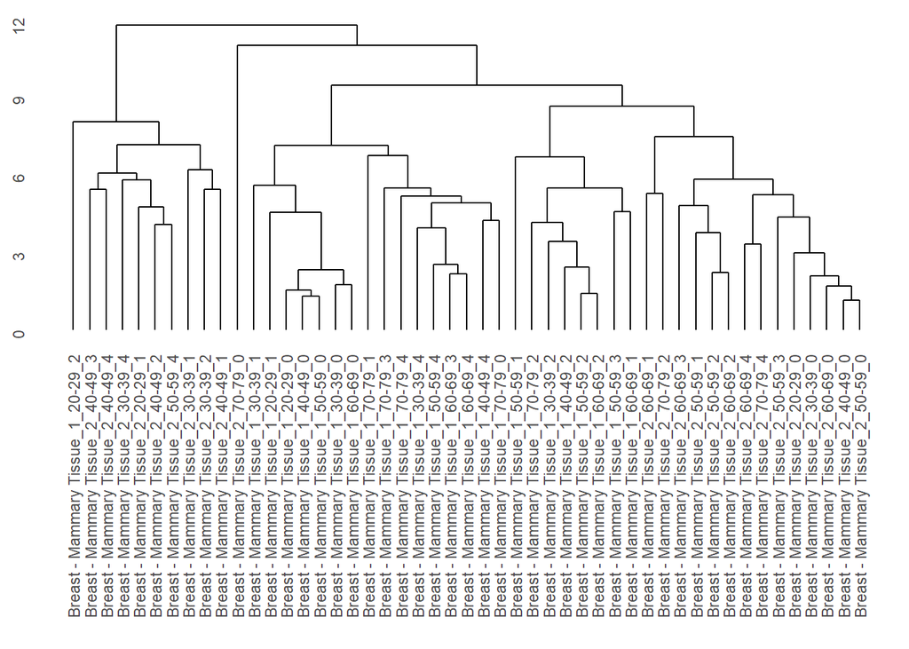

```r
E_matrix <- mean_vals_t %>%
  as.matrix() %>%
  scale() # scale and center the data so that each gene has a mean of 0 and a standard deviation of 1. This prevents genes with high expression from having an undue influence on our results
gene_hclust_row <- E_matrix %>% dist() %>% hclust()

gene_hclust_col <- E_matrix %>% t()  %>% dist() %>% hclust()
ggdendrogram(gene_hclust_col)
```

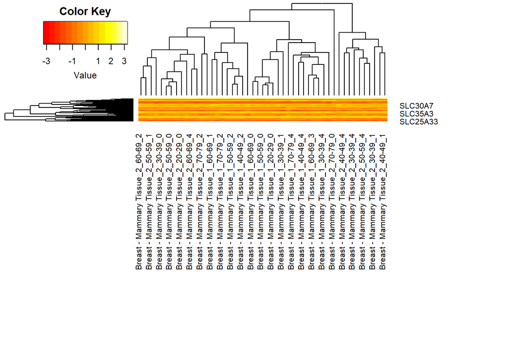

```r
#set.seed(12456) #This ensure that we will have consistent results with one another

#fit <- pvclust(E_matrix, method.hclust = "ward.D", method.dist = "euclidean", nboot = 100)

#plot(fit, print.num=FALSE) # dendogram with p-values

heatmap.2(E_matrix, Rowv = as.dendrogram(gene_hclust_col),  density.info="none",
          trace="none", margins = c(20,10))
```

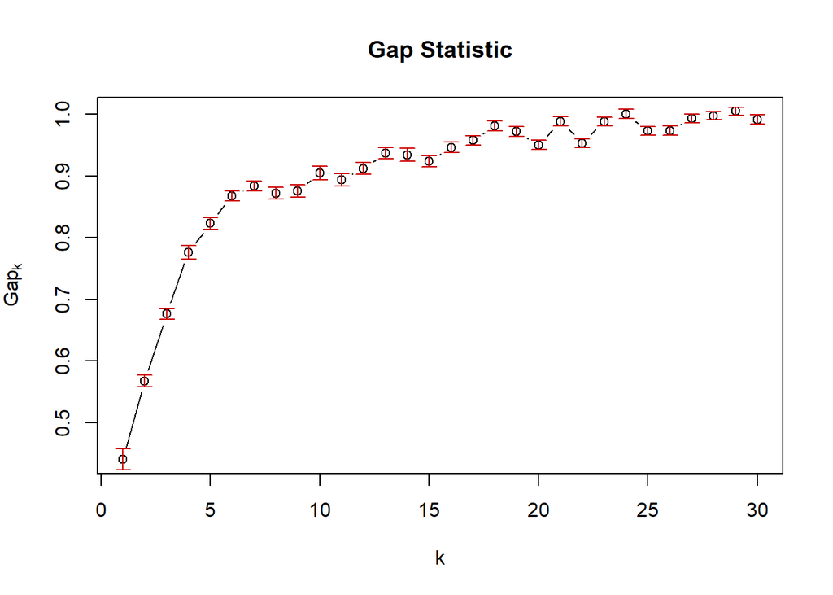

```r
# K-means section

## get principle components
prcomp_counts <- prcomp(E_matrix)
scores <- as.data.frame(prcomp_counts$x)[,c(1,2)]

## Get appropriate cluster number
#set.seed(125)
gap <- clusGap(E_matrix, FUN=kmeans, iter.max=10000, K.max=30, B=100)

plot(gap, main = "Gap Statistic")
```

```r
with(gap, maxSE(Tab[,"gap"], Tab[,"SE.sim"], method="firstSEmax"))
```

```
## [1] 7
```